# Determinantes del Precio de Inmuebles en Bogotá

Análisis de Regresión 2026-1

2026-03-14

# Introducción

Este reporte analiza los determinantes del precio de venta de inmuebles en Bogotá, Colombia, usando un modelo de regresión lineal múltiple. La pregunta de investigación es:

> **¿Qué características de un inmueble explican en mayor medida su precio de venta en Bogotá?**

Los datos fueron recolectados mediante web scraping de portales inmobiliarios colombianos en 2023 y están disponibles en Kaggle (`juandavsnchez/real-estatehousing-colombia-bogota`). El dataset original contiene 585 observaciones; tras eliminar registros con valores faltantes en variables clave, se trabaja con **551 inmuebles**.

Las **unidades estadísticas** son inmuebles individuales (apartamentos, casas y casas en conjunto cerrado) ofertados en el mercado bogotano durante el año 2023.

# Paquetes y datos

```r
library(MASS)
library(readr)
library(tidyverse)
library(ggplot2)
library(gridExtra)
library(car)
library(lmtest)
library(sandwich)
library(nortest)
library(tseries)
library(corrplot)
```

```r
df_raw <- read_csv("C:/Users/felip/Regression-proyect-housing-Bogota/data/raw/properties.csv")
summary(df_raw)
```

```
##    conjunto         administración       estrato        antiguedad
##  Length:585         Min.   :      0   Min.   :1.000   Min.   : 0.00
##  Class :character   1st Qu.:  74000   1st Qu.:2.000   1st Qu.: 7.00
##  Mode  :character   Median : 135000   Median :3.000   Median :13.00
##                     Mean   : 205470   Mean   :3.129   Mean   :15.13
##                     3rd Qu.: 272000   3rd Qu.:4.000   3rd Qu.:21.00
##                     Max.   :1976535   Max.   :6.000   Max.   :48.00
##                                       NA's   :2
##   remodelado             área         habitaciones       baños
##  Length:585         Min.   : 26.00   Min.   :1.000   Min.   :0.000
##  Class :character   1st Qu.: 47.00   1st Qu.:2.000   1st Qu.:1.000
##  Mode  :character   Median : 55.00   Median :3.000   Median :2.000
##                     Mean   : 60.46   Mean   :2.593   Mean   :1.648
##                     3rd Qu.: 70.00   3rd Qu.:3.000   3rd Qu.:2.000
##                     Max.   :207.00   Max.   :8.000   Max.   :4.000
##
##     garajes         elevadores     tipo_de_inmueble      deposito
##  Min.   :0.0000   Min.   :0.0000   Length:585         Min.   :0.0000
##  1st Qu.:0.0000   1st Qu.:0.0000   Class :character   1st Qu.:0.0000
##  Median :0.0000   Median :0.0000   Mode  :character   Median :0.0000
##  Mean   :0.4821   Mean   :0.5709                      Mean   :0.1915
##  3rd Qu.:1.0000   3rd Qu.:1.0000                      3rd Qu.:0.0000
##  Max.   :3.0000   Max.   :4.0000                      Max.   :1.0000
##
##    porteria         zona_de_lavanderia     gas            parqueadero
##  Length:585         Length:585         Length:585         Length:585
##  Class :character   Class :character   Class :character   Class :character
##  Mode  :character   Mode  :character   Mode  :character   Mode  :character
##
##
##
##
##      precio           direccion            nombre          descripcion
##  Min.   :8.500e+07   Length:585         Length:585         Length:585
##  1st Qu.:1.520e+08   Class :character   Class :character   Class :character
##  Median :2.184e+08   Mode  :character   Mode  :character   Mode  :character
##  Mean   :2.608e+08
##  3rd Qu.:3.520e+08
##  Max.   :1.530e+09
##
##     barrio
##  Length:585
##  Class :character
##  Mode  :character
##
##
##
##
```

## Limpieza y preparación de datos

```r
df <- df_raw %>%
  dplyr::select(-conjunto, -direccion, -nombre, -descripcion, -barrio) %>%
  # Convertir cadenas vacías a NA antes de filtrar
  mutate(
    remodelado = na_if(remodelado, ""),
    gas        = na_if(gas, "")
  ) %>%
  filter(!is.na(estrato), !is.na(remodelado), !is.na(gas)) %>%
  mutate(
    remodelado    = ifelse(remodelado  == "Si",  1L, 0L),
    # deposito ya viene como '0'/'1' en el CSV, no como 'Si'/'No'
    deposito      = as.integer(deposito),
    porteria      = ifelse(porteria    == "24 hrs", 1L, 0L),
    zona_lav      = ifelse(zona_de_lavanderia == "Comunal", 1L, 0L),
    gas           = ifelse(gas         == "Si",  1L, 0L),
    parqueadero   = ifelse(parqueadero == "Si",  1L, 0L),
    casa          = ifelse(tipo_de_inmueble == "Casa", 1L, 0L),
    casa_conjunto = ifelse(tipo_de_inmueble == "casa con conjunto cerrado", 1L, 0L),
    log_precio    = log(precio)
  ) %>%
  dplyr::select(-zona_de_lavanderia, -tipo_de_inmueble)

cat( nrow(df), "\n")
```

```
## 551
```

## Variables del modelo

- `log_precio`: logaritmo natural del precio de venta en COP — **variable dependiente**.
- `area`: metros cuadrados del inmueble.
- `habitaciones`: número de habitaciones.
- `banos`: número de baños.
- `garajes`: número de garajes.
- `administracion`: cuota mensual de administración (COP).
- `antiguedad`: años de construcción.
- `elevadores`: número de ascensores en el edificio.
- `estrato`: estrato socioeconómico (1 al 6).
- `remodelado`, `deposito`, `porteria`, `zona_lav`, `gas`, `parqueadero`: variables binarias (0/1).
- `casa`, `casa_conjunto`: dummies de tipo de inmueble (referencia: Apartamento).

```r
df <- df %>%
  rename(
    area           = `área`,
    banos          = `baños`,
    administracion = `administración`
  )
```

```r
df %>%
  dplyr::select(precio, log_precio, area, habitaciones, banos, garajes,
                administracion, antiguedad, elevadores, estrato) %>%
  summary()
```

```
##      precio            log_precio         area         habitaciones
##  Min.   :8.500e+07   Min.   :18.26   Min.   : 26.00   Min.   :1.000
##  1st Qu.:1.509e+08   1st Qu.:18.83   1st Qu.: 46.00   1st Qu.:2.000
##  Median :2.111e+08   Median :19.17   Median : 54.00   Median :3.000
##  Mean   :2.579e+08   Mean   :19.23   Mean   : 60.15   Mean   :2.595
##  3rd Qu.:3.405e+08   3rd Qu.:19.65   3rd Qu.: 69.00   3rd Qu.:3.000
##  Max.   :1.530e+09   Max.   :21.15   Max.   :207.00   Max.   :8.000
##      banos          garajes       administracion      antiguedad
##  Min.   :0.000   Min.   :0.0000   Min.   :      0   Min.   : 0.0
##  1st Qu.:1.000   1st Qu.:0.0000   1st Qu.:  74500   1st Qu.: 7.0
##  Median :2.000   Median :0.0000   Median : 132900   Median :13.0
##  Mean   :1.637   Mean   :0.4682   Mean   : 203432   Mean   :15.1
##  3rd Qu.:2.000   3rd Qu.:1.0000   3rd Qu.: 268550   3rd Qu.:21.0
##  Max.   :4.000   Max.   :3.0000   Max.   :1976535   Max.   :48.0
##    elevadores        estrato
##  Min.   :0.0000   Min.   :1.000
##  1st Qu.:0.0000   1st Qu.:2.000
##  Median :0.0000   Median :3.000
##  Mean   :0.5681   Mean   :3.096
##  3rd Qu.:1.0000   3rd Qu.:4.000
##  Max.   :4.0000   Max.   :6.000
```

# Análisis Exploratorio de los Datos

## Distribución de la variable dependiente

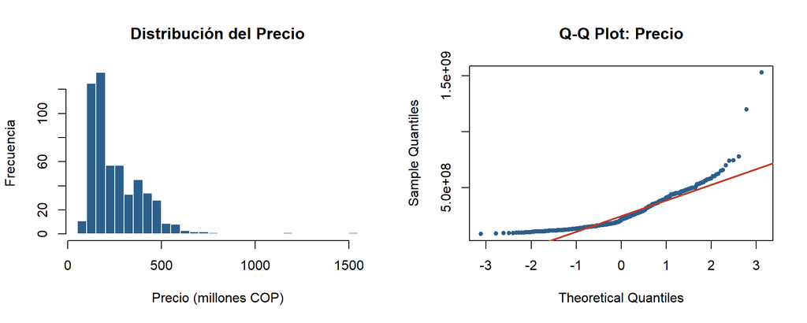

```r
par(mfrow = c(1, 2))

hist(df$precio / 1e6,
     main = "Distribución del Precio",
     xlab = "Precio (millones COP)",
     ylab = "Frecuencia",
     col  = "#2C5F8A", border = "white", breaks = 35)

qqnorm(df$precio, main = "Q-Q Plot: Precio", pch = 20, col = "#2C5F8A")
qqline(df$precio, col = "#C0392B", lwd = 2)
```

```r
par(mfrow = c(1, 1))
```

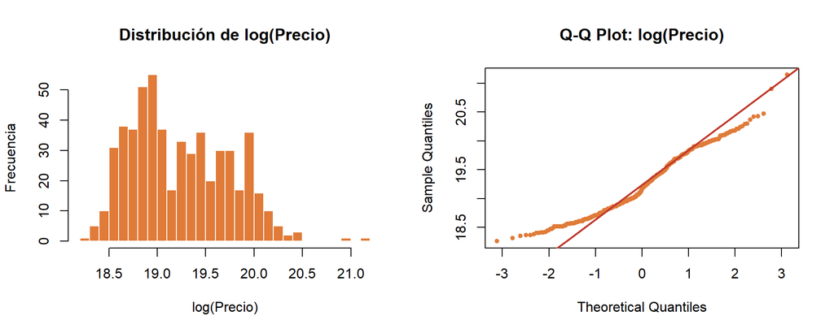

```r
par(mfrow = c(1, 2))

hist(df$log_precio,
     main = "Distribución de log(Precio)",
     xlab = "log(Precio)",
     ylab = "Frecuencia",
     col  = "#E07B39", border = "white", breaks = 35)

qqnorm(df$log_precio, main = "Q-Q Plot: log(Precio)", pch = 20, col = "#E07B39")
qqline(df$log_precio, col = "#C0392B", lwd = 2)
```

```r
par(mfrow = c(1, 1))
```

Se aplica la prueba de Shapiro-Wilk para contrastar formalmente la normalidad:

```r
set.seed(42)
idx <- sample(1:nrow(df), 300)

cat("Precio original:\n")
```

```
## Precio original:
```

```r
print(shapiro.test(df$precio[idx]))
```

```
##
##  Shapiro-Wilk normality test
##
## data:  df$precio[idx]
## W = 0.75464, p-value < 2.2e-16
```

```r
cat("\nlog(Precio):\n")
```

```
##
## log(Precio):
```

```r
print(shapiro.test(df$log_precio[idx]))
```

```
##
##  Shapiro-Wilk normality test
##
## data:  df$log_precio[idx]
## W = 0.95878, p-value = 1.695e-07
```

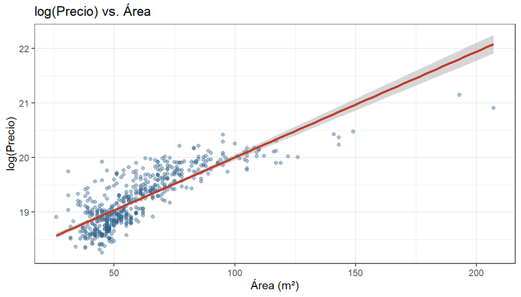

```r
ggplot(df, aes(x = area, y = log_precio)) +
  geom_point(alpha = 0.4, color = "#2C5F8A") +
  geom_smooth(method = "lm", formula = y ~ x, se = TRUE, color = "#C0392B") +
  labs(title = "log(Precio) vs. Área",
       x = "Área (m²)", y = "log(Precio)") +
  theme_bw()
```

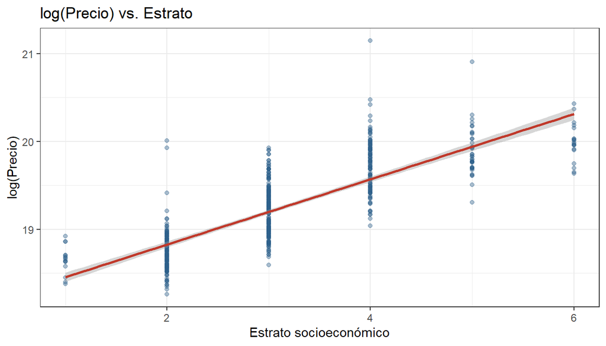

```r
ggplot(df, aes(x = estrato, y = log_precio)) +
  geom_point(alpha = 0.4, color = "#2C5F8A") +
  geom_smooth(method = "lm", formula = y ~ x, se = TRUE, color = "#C0392B") +
  labs(title = "log(Precio) vs. Estrato",
       x = "Estrato socioeconómico", y = "log(Precio)") +
  theme_bw()
```

El estrato presenta una de las correlaciones más altas con el precio. Cada nivel adicional de estrato se asocia con un incremento sustancial en el precio, reflejando las diferencias socioeconómicas espaciales de Bogotá.

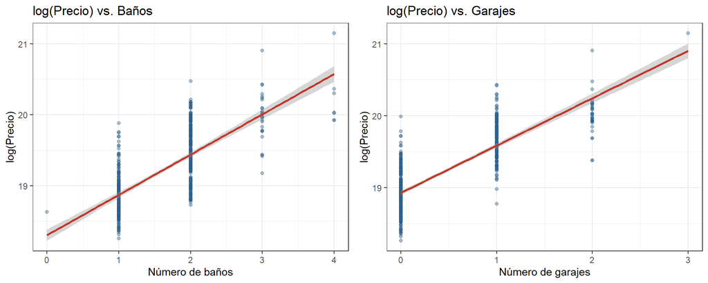

```r
p1 <- ggplot(df, aes(x = banos, y = log_precio)) +
  geom_point(alpha = 0.4, color = "#2C5F8A") +
  geom_smooth(method = "lm", formula = y ~ x, se = TRUE, color = "#C0392B") +
  labs(title = "log(Precio) vs. Baños",
       x = "Número de baños", y = "log(Precio)") +
  theme_bw()

p2 <- ggplot(df, aes(x = garajes, y = log_precio)) +
  geom_point(alpha = 0.4, color = "#2C5F8A") +
  geom_smooth(method = "lm", formula = y ~ x, se = TRUE, color = "#C0392B") +
  labs(title = "log(Precio) vs. Garajes",
       x = "Número de garajes", y = "log(Precio)") +
  theme_bw()

grid.arrange(p1, p2, ncol = 2)
```

Tanto baños como garajes muestran relaciones lineales positivas claras con el precio. Los garajes tienen una pendiente especialmente pronunciada, dado el alto valor del parqueo en Bogotá.

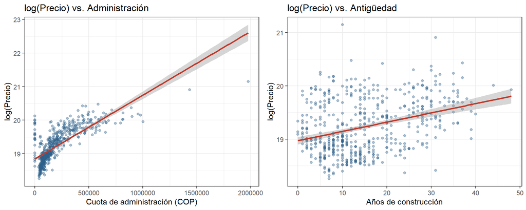

```r
p3 <- ggplot(df, aes(x = administracion, y = log_precio)) +
  geom_point(alpha = 0.4, color = "#2C5F8A") +
  geom_smooth(method = "lm", formula = y ~ x, se = TRUE, color = "#C0392B") +
  labs(title = "log(Precio) vs. Administración",
       x = "Cuota de administración (COP)", y = "log(Precio)") +
  theme_bw()

p4 <- ggplot(df, aes(x = antiguedad, y = log_precio)) +
  geom_point(alpha = 0.4, color = "#2C5F8A") +
  geom_smooth(method = "lm", formula = y ~ x, se = TRUE, color = "#C0392B") +
  labs(title = "log(Precio) vs. Antigüedad",
       x = "Años de construcción", y = "log(Precio)") +
  theme_bw()

grid.arrange(p3, p4, ncol = 2)
```

La administración presenta una relación positiva pero con alta dispersión en valores extremos. La antigüedad muestra una relación positiva débil.

## Validación de relaciones lineales vs. no lineales

Para detectar si alguna variable presenta una relación no lineal con `log_precio`, se superponen la recta de regresión lineal (**roja**) y una curva LOESS no paramétrica (**azul punteada**). Si ambas coinciden, la relación es lineal; si la curva LOESS se desvía de la recta, hay evidencia de no linealidad.

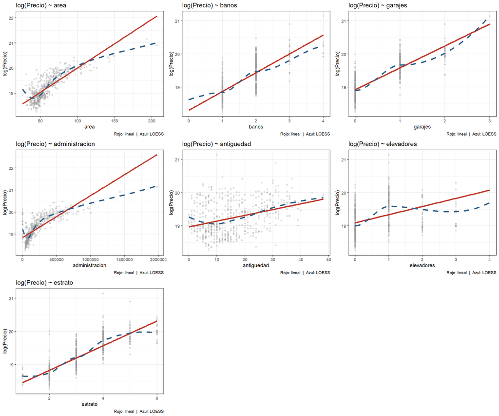

```r
vars_check <- c("area", "banos", "garajes", "administracion",
                "antiguedad", "elevadores", "estrato")

plots_nl <- lapply(vars_check, function(xv) {
  ggplot(df, aes(x = .data[[xv]], y = log_precio)) +
    geom_point(alpha = 0.3, size = 1, color = "gray60") +
    geom_smooth(method = "lm",    formula = y ~ x, se = FALSE,
                color = "#C0392B", linewidth = 1.2, linetype = "solid") +
    geom_smooth(method = "loess", formula = y ~ x, se = FALSE,
                color = "#2C5F8A", linewidth = 1.2, linetype = "dashed") +
    labs(title = paste("log(Precio) ~", xv),
         x = xv, y = "log(Precio)",
         caption = "Rojo: lineal  |  Azul: LOESS") +
    theme_bw(base_size = 9)
})

grid.arrange(grobs = plots_nl, ncol = 3)
```

## Validación de transformaciones de variables

Se evalúa si las variables con mayor dispersión se benefician de una transformación logarítmica, comparando la escala original versus la escala logarítmica.

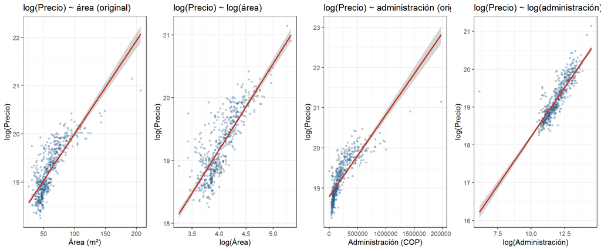

```r
p_area_orig <- ggplot(df, aes(x = area, y = log_precio)) +
  geom_point(alpha = 0.3, size = 1, color = "#2C5F8A") +
  geom_smooth(method = "lm", formula = y ~ x, se = TRUE, color = "#C0392B") +
  labs(title = "log(Precio) ~ área (original)",
       x = "Área (m²)", y = "log(Precio)") +
  theme_bw()

p_area_log <- ggplot(df, aes(x = log(area), y = log_precio)) +
  geom_point(alpha = 0.3, size = 1, color = "#2C5F8A") +
  geom_smooth(method = "lm", formula = y ~ x, se = TRUE, color = "#C0392B") +
  labs(title = "log(Precio) ~ log(área)",
       x = "log(Área)", y = "log(Precio)") +
  theme_bw()

df_adm <- df %>% filter(administracion > 0)

p_adm_orig <- ggplot(df_adm, aes(x = administracion, y = log_precio)) +
  geom_point(alpha = 0.3, size = 1, color = "#2C5F8A") +
  geom_smooth(method = "lm", formula = y ~ x, se = TRUE, color = "#C0392B") +
  labs(title = "log(Precio) ~ administración (original)",
       x = "Administración (COP)", y = "log(Precio)") +
  theme_bw()

p_adm_log <- ggplot(df_adm, aes(x = log(administracion), y = log_precio)) +
  geom_point(alpha = 0.3, size = 1, color = "#2C5F8A") +
  geom_smooth(method = "lm", formula = y ~ x, se = TRUE, color = "#C0392B") +
  labs(title = "log(Precio) ~ log(administración)",
       x = "log(Administración)", y = "log(Precio)") +
  theme_bw()

grid.arrange(p_area_orig, p_area_log, p_adm_orig, p_adm_log, ncol = 4)
```

Para `area`, la relación en escala original ya es lineal; `log(area)` produce una nube ligeramente más compacta. Para `administracion`, la versión log reduce la dispersión producida por valores extremos. Sin embargo, dado que los VIF son bajos y la relación lineal es aceptable, **se mantienen ambas variables en escala original** para preservar la interpretabilidad directa de los coeficientes.

## Gráficos de dispersión entre variables explicativas

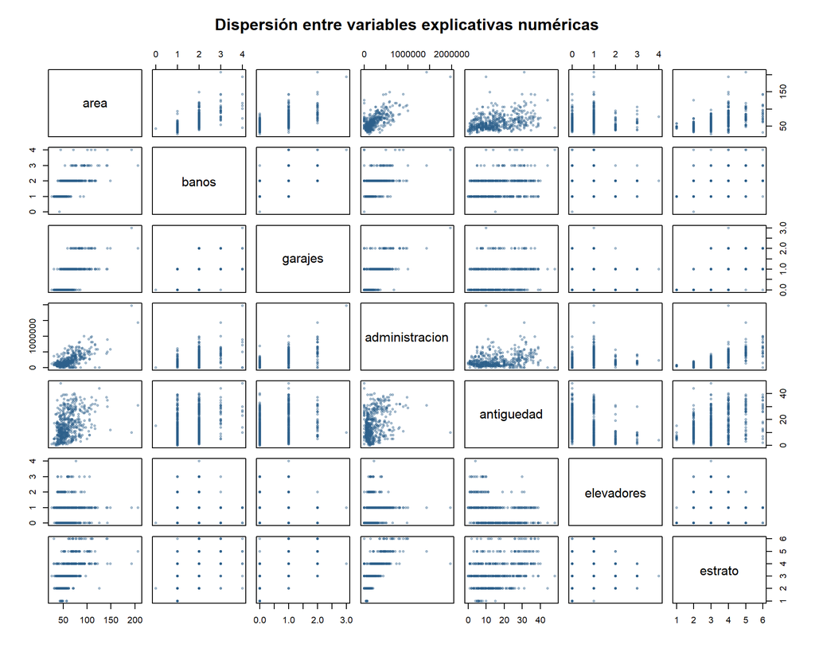

```r
df %>%
  dplyr::select(area, banos, garajes, administracion, antiguedad,
                elevadores, estrato) %>%
  pairs(pch = 20, col = adjustcolor("#2C5F8A", alpha.f = 0.3),
        main = "Dispersión entre variables explicativas numéricas")
```

Se observan asociaciones positivas moderadas entre `area` y `banos` (inmuebles más grandes tienen más baños), entre `garajes` y `estrato` (estratos altos tienen más garajes), y entre `administracion` y `estrato`. Ninguna correlación supera 0.8, lo que anticipa la ausencia de multicolinealidad grave entre los predictores.

## Matriz de correlaciones

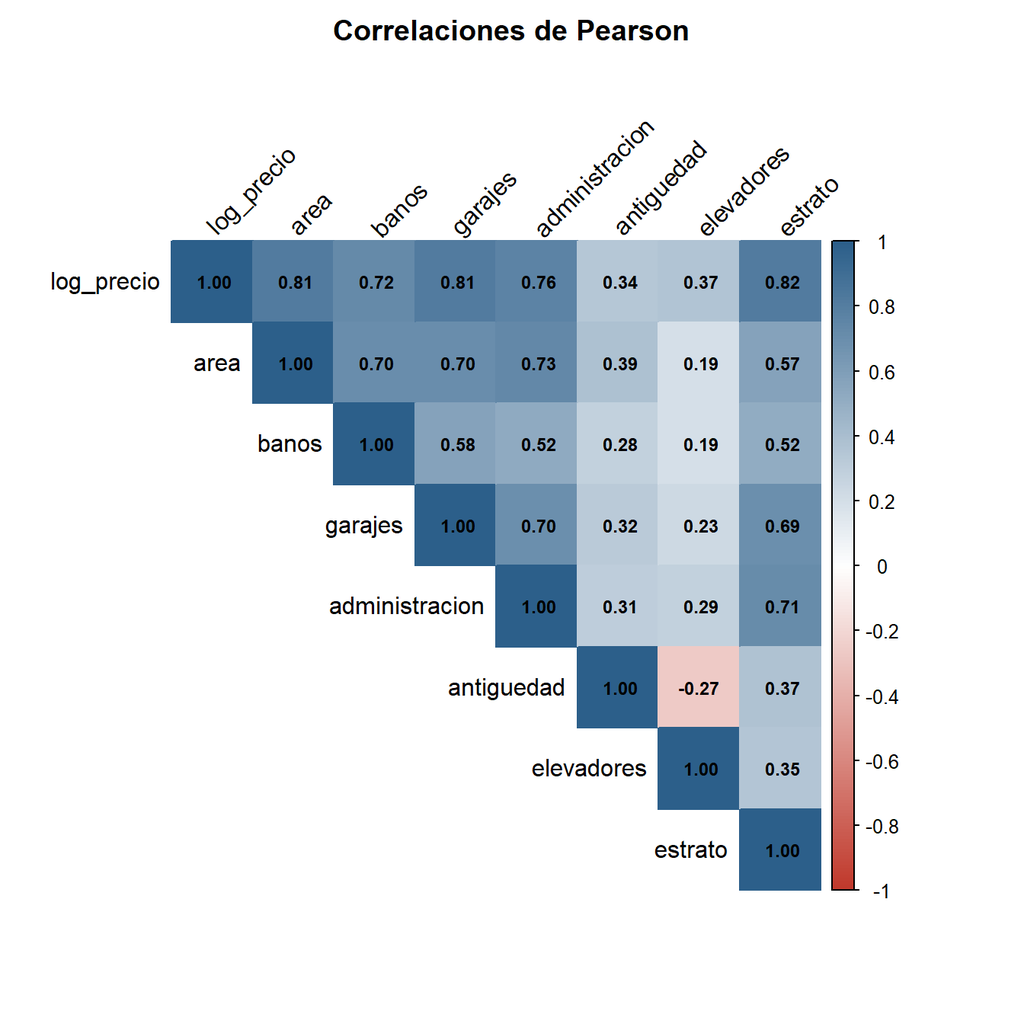

```r
vars_num <- c("log_precio", "area", "banos", "garajes",
              "administracion", "antiguedad", "elevadores", "estrato")

corr_mat <- cor(df %>% dplyr::select(all_of(vars_num)), use = "complete.obs")

par(mar = c(0, 0, 2, 0))
corrplot(corr_mat,
         method      = "color",
         type        = "upper",
         addCoef.col = "black",
         number.cex  = 0.75,
         tl.col      = "black",
         tl.srt      = 45,
         col         = colorRampPalette(c("#C0392B", "white", "#2C5F8A"))(200))
title("Correlaciones de Pearson")
```

# Estimación de Modelos, Ajuste y Validación

## Usar para el reporte

$$\log(\text{precio}_i) = \beta_0 + \beta_1\,X_{1i} + \beta_2\,X_{2i} +
\cdots + \beta_k\,X_{ki} + \varepsilon_i, \quad \varepsilon_i \sim
\mathcal{N}(0, \sigma^2)$$

## Modelo 0: Precio sin transformar

### Este lo usamos de referencia

$$\text{precio}_i = \beta_0 + \beta_1\,\text{area}_i + \cdots +
\beta_k\,X_{ki} + \varepsilon_i$$

```r
m0 <- lm(precio ~ area + habitaciones + banos + garajes + administracion +
           antiguedad + elevadores + estrato +
           remodelado + deposito + porteria + zona_lav + gas +
           parqueadero + casa + casa_conjunto,
         data = df)

summary(m0)
```

```
##
## Call:
## lm(formula = precio ~ area + habitaciones + banos + garajes +
##     administracion + antiguedad + elevadores + estrato + remodelado +
##     deposito + porteria + zona_lav + gas + parqueadero + casa +
##     casa_conjunto, data = df)
##
## Residuals:
##        Min         1Q     Median         3Q        Max
## -161950327  -24856196     799973   20849671  347827085
##
## Coefficients:
##                  Estimate Std. Error t value Pr(>|t|)
## (Intercept)    -2.817e+07  2.401e+07  -1.173 0.241316
## area            3.455e+06  1.968e+05  17.555  < 2e-16 ***
## habitaciones   -1.249e+07  3.789e+06  -3.297 0.001044 **
## banos           1.767e+07  4.659e+06   3.793 0.000166 ***
## garajes         3.369e+07  5.342e+06   6.306 6.01e-10 ***
## administracion  1.774e+02  1.837e+01   9.657  < 2e-16 ***
## antiguedad     -1.240e+06  2.604e+05  -4.762 2.47e-06 ***
## elevadores      7.178e+06  3.212e+06   2.234 0.025868 *
## estrato         2.011e+07  3.190e+06   6.304 6.10e-10 ***
## remodelado     -5.590e+06  4.117e+06  -1.358 0.175075
## deposito        1.008e+07  6.147e+06   1.640 0.101551
## porteria       -2.243e+07  7.980e+06  -2.811 0.005125 **
## zona_lav        1.685e+07  7.031e+06   2.397 0.016865 *
## gas            -6.244e+05  1.920e+07  -0.033 0.974070
## parqueadero     1.909e+06  4.746e+06   0.402 0.687761
## casa            8.032e+07  1.781e+07   4.510 7.97e-06 ***
## casa_conjunto   2.743e+06  9.507e+06   0.289 0.773064
## ---
## Signif. codes:  0 '***' 0.001 '**' 0.01 '*' 0.05 '.' 0.1 ' ' 1
##
## Residual standard error: 46140000 on 534 degrees of freedom
## Multiple R-squared:  0.9069, Adjusted R-squared:  0.9041
## F-statistic: 325.3 on 16 and 534 DF,  p-value: < 2.2e-16
```

### Validación de supuestos — Modelo 0

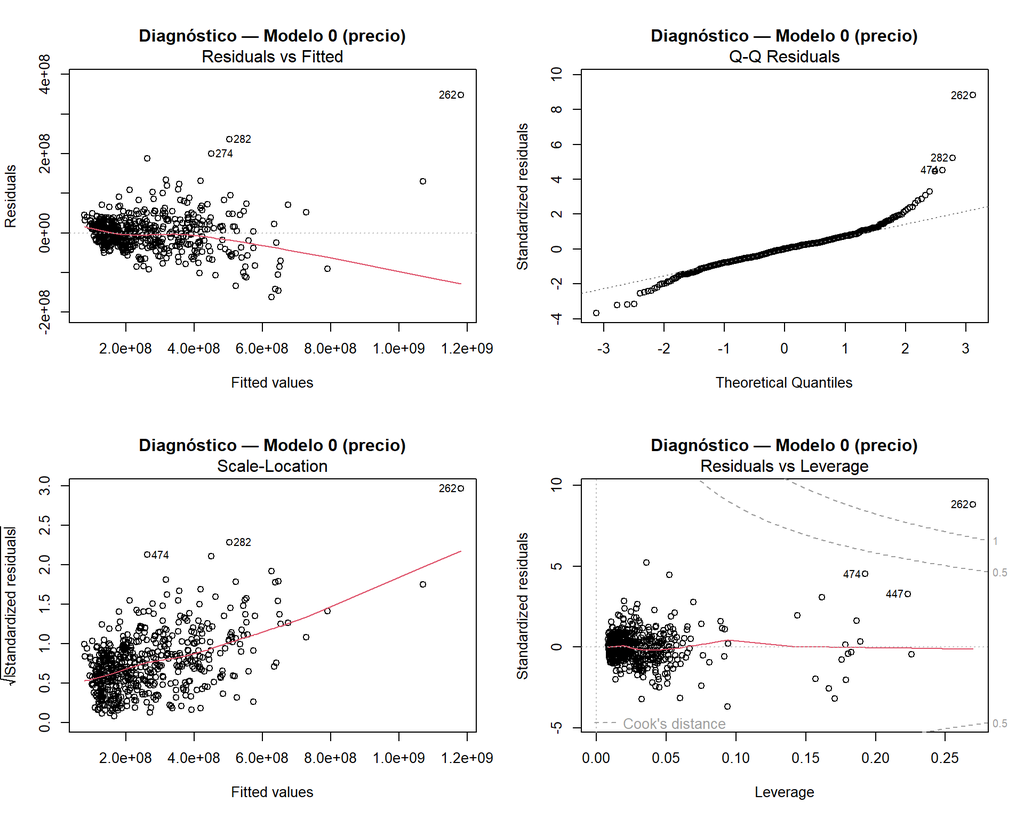

```r
par(mfrow = c(2, 2))
plot(m0, main = "Diagnóstico — Modelo 0 (precio)")
```

```r
par(mfrow = c(1, 1))
```

```r
res_m0 <- residuals(m0)
set.seed(42)
idx_m0 <- sample(seq_along(res_m0), 300)

cat("=== Normalidad ===\n")
```

```
## === Normalidad ===
```

```r
cat("\nShapiro-Wilk:\n")
```

```
##
## Shapiro-Wilk:
```

```r
print(shapiro.test(res_m0[idx_m0]))
```

```
##
##  Shapiro-Wilk normality test
##
## data:  res_m0[idx_m0]
## W = 0.90299, p-value = 5.836e-13
```

```r
cat("\nJarque-Bera:\n")
```

```
##
## Jarque-Bera:
```

```r
print(tseries::jarque.bera.test(res_m0))
```

```
##
##  Jarque Bera Test
##
## data:  res_m0
## X-squared = 1835, df = 2, p-value < 2.2e-16
```

```r
cat("\nAnderson-Darling:\n")
```

```
##
## Anderson-Darling:
```

```r
print(nortest::ad.test(res_m0))
```

```
##
##  Anderson-Darling normality test
##
## data:  res_m0
## A = 6.7246, p-value < 2.2e-16
```

```r
cat("\n=== Homocedasticidad ===\n")
```

```
##
## === Homocedasticidad ===
```

```r
cat("\nBreusch-Pagan:\n")
```

```
##
## Breusch-Pagan:
```

```r
print(lmtest::bptest(m0))
```

```
##
##  studentized Breusch-Pagan test
##
## data:  m0
## BP = 204.07, df = 16, p-value < 2.2e-16
```

```r
cat("\n=== Independencia de errores ===\n")
```

```
##
## === Independencia de errores ===
```

```r
cat("\nDurbin-Watson:\n")
```

```
##
## Durbin-Watson:
```

```r
print(lmtest::dwtest(m0))
```

```
##
##  Durbin-Watson test
##
## data:  m0
## DW = 2.1313, p-value = 0.9368
## alternative hypothesis: true autocorrelation is greater than 0
```

El Modelo 0 viola los supuestos de normalidad (p < 0.001) y homocedasticidad (p < 0.001), por lo que **sus inferencias son inválidas**. Se confirma la necesidad de la transformación logarítmica.

## Modelo 1: log(precio) — Modelo completo

$$\log(\text{precio}_i) = \beta_0 + \beta_1\,\text{area}_i +
\beta_2\,\text{habitaciones}_i + \beta_3\,\text{banos}_i +
\beta_4\,\text{garajes}_i + \beta_5\,\text{administracion}_i \\
+ \beta_6\,\text{antiguedad}_i + \beta_7\,\text{elevadores}_i +
\beta_8\,\text{estrato}_i + \beta_9\,\text{remodelado}_i +
\beta_{10}\,\text{deposito}_i \\
+ \beta_{11}\,\text{porteria}_i + \beta_{12}\,\text{zona\_lav}_i +
\beta_{13}\,\text{gas}_i + \beta_{14}\,\text{parqueadero}_i +
\beta_{15}\,\text{casa}_i + \beta_{16}\,\text{casa\_conjunto}_i +
\varepsilon_i$$

```r
m1 <- lm(log_precio ~ area + habitaciones + banos + garajes + administracion +
           antiguedad + elevadores + estrato +
           remodelado + deposito + porteria + zona_lav + gas +
           parqueadero + casa + casa_conjunto,
         data = df)

summary(m1)
```

```
##
## Call:
## lm(formula = log_precio ~ area + habitaciones + banos + garajes +
##     administracion + antiguedad + elevadores + estrato + remodelado +
##     deposito + porteria + zona_lav + gas + parqueadero + casa +
##     casa_conjunto, data = df)
##
## Residuals:
##      Min       1Q   Median       3Q      Max
## -0.55319 -0.10998 -0.00495  0.11236  0.48610
##
## Coefficients:
##                  Estimate Std. Error t value Pr(>|t|)
## (Intercept)     1.800e+01  8.601e-02 209.226  < 2e-16 ***
## area            7.126e-03  7.049e-04  10.109  < 2e-16 ***
## habitaciones   -7.009e-03  1.357e-02  -0.516  0.60575
## banos           1.249e-01  1.669e-02   7.487 2.93e-13 ***
## garajes         1.706e-01  1.913e-02   8.914  < 2e-16 ***
## administracion  8.917e-08  6.580e-08   1.355  0.17594
## antiguedad     -1.099e-03  9.327e-04  -1.178  0.23922
## elevadores      6.391e-02  1.151e-02   5.554 4.40e-08 ***
## estrato         1.631e-01  1.143e-02  14.276  < 2e-16 ***
## remodelado      1.215e-03  1.474e-02   0.082  0.93438
## deposito        1.836e-02  2.202e-02   0.834  0.40475
## porteria       -7.530e-02  2.858e-02  -2.635  0.00867 **
## zona_lav        5.979e-02  2.518e-02   2.375  0.01792 *
## gas             5.981e-02  6.877e-02   0.870  0.38486
## parqueadero    -8.464e-03  1.700e-02  -0.498  0.61875
## casa            2.067e-01  6.378e-02   3.241  0.00127 **
## casa_conjunto   9.842e-02  3.405e-02   2.890  0.00400 **
## ---
## Signif. codes:  0 '***' 0.001 '**' 0.01 '*' 0.05 '.' 0.1 ' ' 1
##
## Residual standard error: 0.1653 on 534 degrees of freedom
## Multiple R-squared:  0.8956, Adjusted R-squared:  0.8925
## F-statistic: 286.3 on 16 and 534 DF,  p-value: < 2.2e-16
```

### Prueba F global — Modelo 1

La prueba F contrasta $H_0: \beta_1 = \cdots = \beta_{16} = 0$ vs. $H_1:$ al menos un $\beta_j \neq 0$.

```r
anova(lm(log_precio ~ 1, data = df), m1)
```

```
## Analysis of Variance Table
##
## Model 1: log_precio ~ 1
## Model 2: log_precio ~ area + habitaciones + banos + garajes + administracion +
##     antiguedad + elevadores + estrato + remodelado + deposito +
##     porteria + zona_lav + gas + parqueadero + casa + casa_conjunto
##   Res.Df     RSS Df Sum of Sq     F    Pr(>F)
## 1    550 139.693
## 2    534  14.584 16    125.11 286.3 < 2.2e-16 ***
## ---
## Signif. codes:  0 '***' 0.001 '**' 0.01 '*' 0.05 '.' 0.1 ' ' 1
```

La prueba F resulta altamente significativa (p < 0.001): el modelo en conjunto explica una proporción real de la variabilidad del precio.

### Pruebas individuales de significancia — Modelo 1

Del `summary(m1)` se identifican las variables con p-valor > 0.05 (no significativas al nivel $\alpha = 0.05$):

- `habitaciones` (p = 0.606)
- `administracion` (p = 0.176)
- `antiguedad` (p = 0.239)
- `remodelado` (p = 0.934)
- `deposito` (p = 0.405)
- `gas` (p = 0.385)
- `parqueadero` (p = 0.619)

### Validación de supuestos — Modelo 1

#### Linealidad

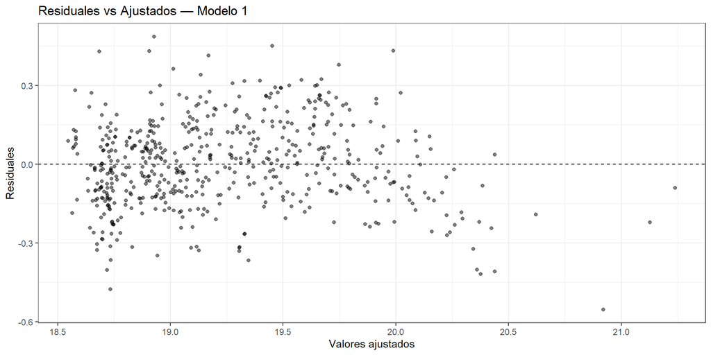

```r
# Residuales vs valores ajustados
fit_m1 <- fitted(m1)
res_m1  <- residuals(m1)

ggplot(data.frame(fit = fit_m1, res = res_m1), aes(fit, res)) +
  geom_hline(yintercept = 0, linetype = "dashed") +
  geom_point(alpha = 0.5) +
  labs(x = "Valores ajustados", y = "Residuales",
       title = "Residuales vs Ajustados — Modelo 1") +
  theme_bw()
```

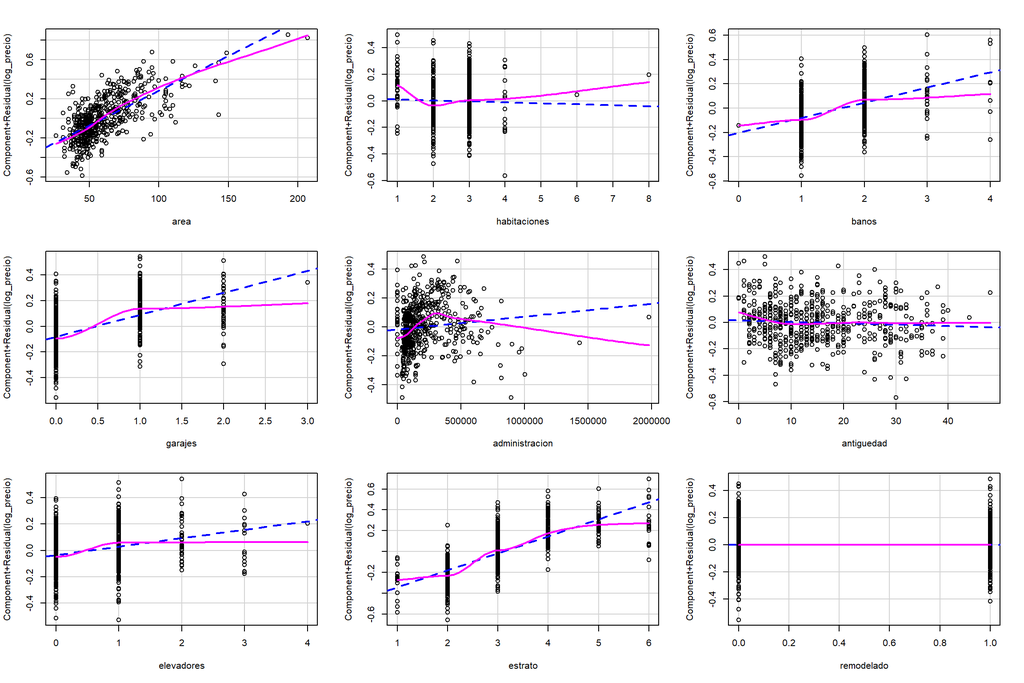

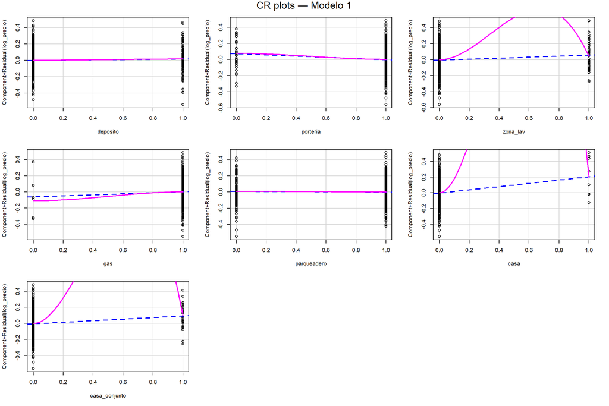

```r
# CR plots para verificar linealidad por predictor (solo variables continuas)
par(mfrow = c(1, 1))
car::crPlots(m1, ask = FALSE, smooth = TRUE,
             main = "CR plots — Modelo 1", id = FALSE)
```

```r
cat("Prueba RESET de Ramsey (potencias 2 y 3):\n")
```

```
## Prueba RESET de Ramsey (potencias 2 y 3):
```

```r
print(lmtest::resettest(m1, power = 2:3))
```

```
##
##  RESET test
##
## data:  m1
## RESET = 64.107, df1 = 2, df2 = 532, p-value < 2.2e-16
```

#### Homocedasticidad

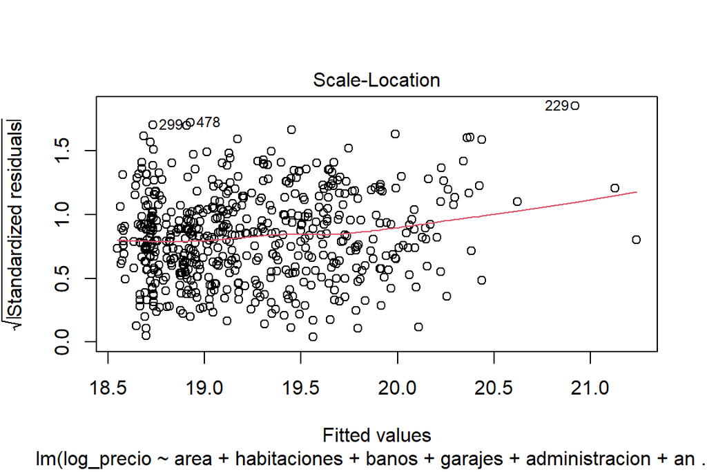

```r
plot(m1, which = 3)
```

```r
cat("Breusch-Pagan:\n")
```

```
## Breusch-Pagan:
```

```r
print(lmtest::bptest(m1))
```

```
##
##  studentized Breusch-Pagan test
##
## data:  m1
## BP = 30.528, df = 16, p-value = 0.01545
```

#### Independencia de errores

```r
cat("Durbin-Watson:\n")
```

```
## Durbin-Watson:
```

```r
print(lmtest::dwtest(m1))
```

```
##
##  Durbin-Watson test
##
## data:  m1
## DW = 2.0641, p-value = 0.77
## alternative hypothesis: true autocorrelation is greater than 0
```

#### Normalidad de residuos

```r
set.seed(42)
idx_m1 <- sample(seq_along(res_m1), 300)

cat("Shapiro-Wilk:\n")
```

```
## Shapiro-Wilk:
```

```r
print(shapiro.test(res_m1[idx_m1]))
```

```
##
##  Shapiro-Wilk normality test
##
## data:  res_m1[idx_m1]
## W = 0.99233, p-value = 0.1245
```

```r
cat("\nJarque-Bera:\n")
```

```
##
## Jarque-Bera:
```

```r
print(tseries::jarque.bera.test(res_m1))
```

```
##
##  Jarque Bera Test
##
## data:  res_m1
## X-squared = 0.13135, df = 2, p-value = 0.9364
```

```r
cat("\nAnderson-Darling:\n")
```

```
##
## Anderson-Darling:
```

```r
print(nortest::ad.test(res_m1))
```

```
##
##  Anderson-Darling normality test
##
## data:  res_m1
## A = 0.32717, p-value = 0.5184
```

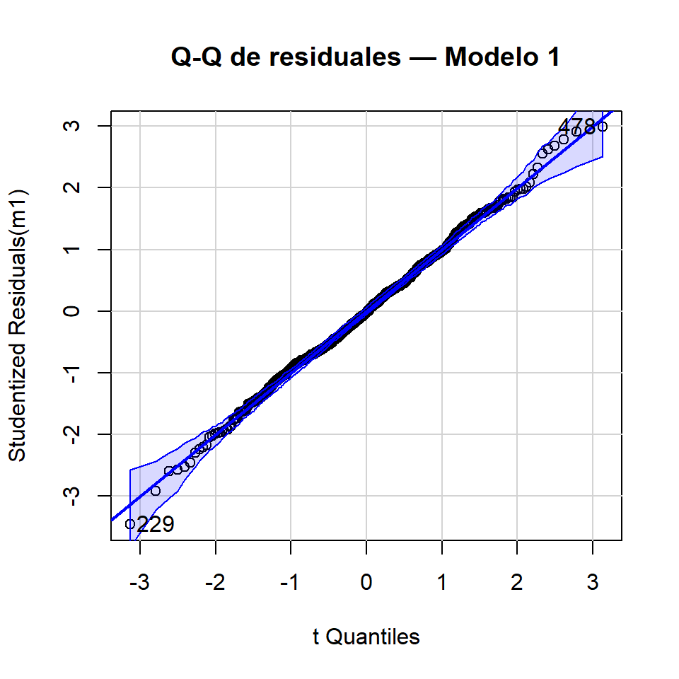

```
## [1] 229 478
```

```r
car::qqPlot(m1, simulate = TRUE, main = "Q-Q de residuales — Modelo 1")
```

### Multicolinealidad — VIF y número de condición

```r
cat("VIF — Modelo 1:\n")
```

```
## VIF — Modelo 1:
```

```r
print(car::vif(m1))
```

```
##           area   habitaciones          banos        garajes administracion
##       4.499049       1.853040       2.318157       2.857816       3.546943
##     antiguedad     elevadores        estrato     remodelado       deposito
##       1.707177       1.518137       3.221482       1.079338       1.475221
##       porteria       zona_lav            gas    parqueadero           casa
##       1.109540       1.055474       1.027653       1.155124       1.174252
##  casa_conjunto
##       1.090008
```

```r
cat("\nNúmero de condición (kappa):\n")
```

```
##
## Número de condición (kappa):
```

```r
print(kappa(model.matrix(m1)))
```

```
## [1] 5222657
```

## Modelo 2: log(precio) — Modelo reducido (modelo final)

$$\log(\text{precio}_i) = \beta_0 + \beta_1\,\text{area}_i +
\beta_2\,\text{banos}_i + \beta_3\,\text{garajes}_i +
\beta_4\,\text{elevadores}_i + \beta_5\,\text{estrato}_i \\
+ \beta_6\,\text{porteria}_i + \beta_7\,\text{zona\_lav}_i +
\beta_8\,\text{casa}_i + \beta_9\,\text{casa\_conjunto}_i +
\varepsilon_i$$

```r
m2 <- lm(log_precio ~ area + banos + garajes + elevadores + estrato +
           porteria + zona_lav + casa + casa_conjunto,
         data = df)

summary(m2)
```

```
##
## Call:
## lm(formula = log_precio ~ area + banos + garajes + elevadores +
##     estrato + porteria + zona_lav + casa + casa_conjunto, data = df)
##
## Residuals:
##      Min       1Q   Median       3Q      Max
## -0.53730 -0.11281 -0.01081  0.10885  0.50663
##
## Coefficients:
##                 Estimate Std. Error t value Pr(>|t|)
## (Intercept)   18.0038325  0.0411226 437.809  < 2e-16 ***
## area           0.0073361  0.0005506  13.324  < 2e-16 ***
## banos          0.1209875  0.0160283   7.548 1.88e-13 ***
## garajes        0.1804669  0.0185350   9.737  < 2e-16 ***
## elevadores     0.0718380  0.0102119   7.035 6.06e-12 ***
## estrato        0.1674653  0.0094491  17.723  < 2e-16 ***
## porteria      -0.0705290  0.0279256  -2.526  0.01183 *
## zona_lav       0.0560386  0.0246757   2.271  0.02354 *
## casa           0.1833459  0.0617153   2.971  0.00310 **
## casa_conjunto  0.0934112  0.0336151   2.779  0.00564 **
## ---
## Signif. codes:  0 '***' 0.001 '**' 0.01 '*' 0.05 '.' 0.1 ' ' 1
##
## Residual standard error: 0.1652 on 541 degrees of freedom
## Multiple R-squared:  0.8944, Adjusted R-squared:  0.8926
## F-statistic:   509 on 9 and 541 DF,  p-value: < 2.2e-16
```

### Prueba F parcial: modelo completo vs. modelo reducido

```r
anova(m2, m1)
```

```
## Analysis of Variance Table
##
## Model 1: log_precio ~ area + banos + garajes + elevadores + estrato +
##     porteria + zona_lav + casa + casa_conjunto
## Model 2: log_precio ~ area + habitaciones + banos + garajes + administracion +
##     antiguedad + elevadores + estrato + remodelado + deposito +
##     porteria + zona_lav + gas + parqueadero + casa + casa_conjunto
##   Res.Df    RSS Df Sum of Sq      F Pr(>F)
## 1    541 14.756
## 2    534 14.584  7   0.17164 0.8978 0.5078
```

La prueba F parcial no rechaza $H_0$ (p > 0.05): las variables eliminadas **no mejoran significativamente** el ajuste. El modelo reducido es preferible por parsimonia.

### Intervalos de confianza — Modelo 2

```r
confint(m2, level = 0.95)
```

```
##                      2.5 %       97.5 %
## (Intercept)   17.923052943 18.084612035
## area           0.006254607  0.008417691
## banos          0.089502183  0.152472834
## garajes        0.144057483  0.216876383
## elevadores     0.051778250  0.091897827
## estrato        0.148903816  0.186026686
## porteria      -0.125384853 -0.015673126
## zona_lav       0.007566555  0.104510586
## casa           0.062114863  0.304576977
## casa_conjunto  0.027379079  0.159443263
```

### Validación de supuestos — Modelo 2 (modelo final)

#### Linealidad

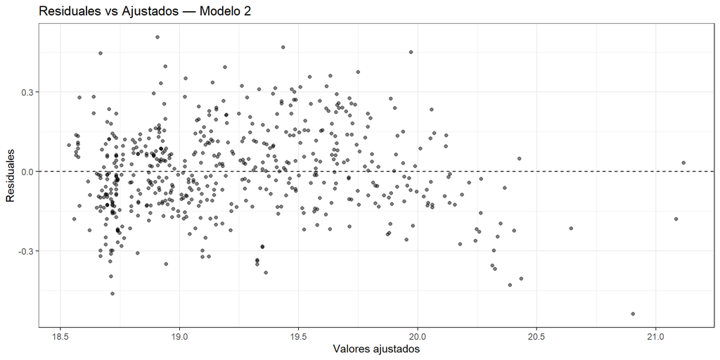

```r
fit_m2 <- fitted(m2)
res_m2  <- residuals(m2)

ggplot(data.frame(fit = fit_m2, res = res_m2), aes(fit, res)) +
  geom_hline(yintercept = 0, linetype = "dashed") +
  geom_point(alpha = 0.5) +
  labs(x = "Valores ajustados", y = "Residuales",
       title = "Residuales vs Ajustados — Modelo 2") +
  theme_bw()
```

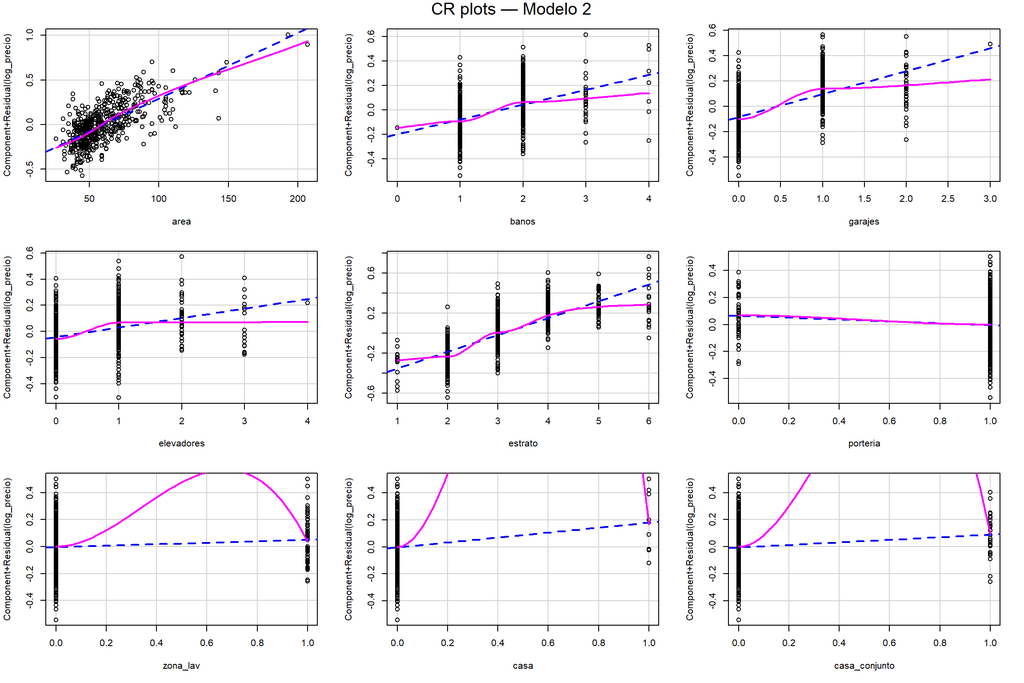

```r
par(mfrow = c(1, 1))
car::crPlots(m2, ask = FALSE, smooth = TRUE,
             main = "CR plots — Modelo 2", id = FALSE)
```

```r
cat("Prueba RESET de Ramsey (potencias 2 y 3):\n")
```

```
## Prueba RESET de Ramsey (potencias 2 y 3):
```

```r
print(lmtest::resettest(m2, power = 2:3))
```

```
##
##  RESET test
##
## data:  m2
## RESET = 38.953, df1 = 2, df2 = 539, p-value < 2.2e-16
```

#### Homocedasticidad

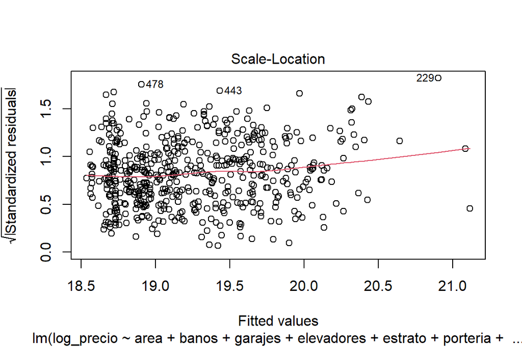

```r
plot(m2, which = 3)
```

```r
cat("Breusch-Pagan:\n")
```

```
## Breusch-Pagan:
```

```r
print(lmtest::bptest(m2))
```

```
##
##  studentized Breusch-Pagan test
##
## data:  m2
## BP = 16.374, df = 9, p-value = 0.05947
```

#### Independencia de errores

```r
cat("Durbin-Watson:\n")
```

```
## Durbin-Watson:
```

```r
print(lmtest::dwtest(m2))
```

```
##
##  Durbin-Watson test
##
## data:  m2
## DW = 2.0636, p-value = 0.7706
## alternative hypothesis: true autocorrelation is greater than 0
```

#### Normalidad de residuos

```r
set.seed(42)
idx_m2 <- sample(seq_along(res_m2), 300)

cat("Shapiro-Wilk:\n")
```

```
## Shapiro-Wilk:
```

```r
print(shapiro.test(res_m2[idx_m2]))
```

```
##
##  Shapiro-Wilk normality test
##
## data:  res_m2[idx_m2]
## W = 0.99294, p-value = 0.1692
```

```r
cat("\nJarque-Bera:\n")
```

```
##
## Jarque-Bera:
```

```r
print(tseries::jarque.bera.test(res_m2))
```

```
##
##  Jarque Bera Test
##
## data:  res_m2
## X-squared = 0.33047, df = 2, p-value = 0.8477
```

```r
cat("\nAnderson-Darling:\n")
```

```
##
## Anderson-Darling:
```

```r
print(nortest::ad.test(res_m2))
```

```
##
##  Anderson-Darling normality test
##
## data:  res_m2
## A = 0.39738, p-value = 0.3666
```

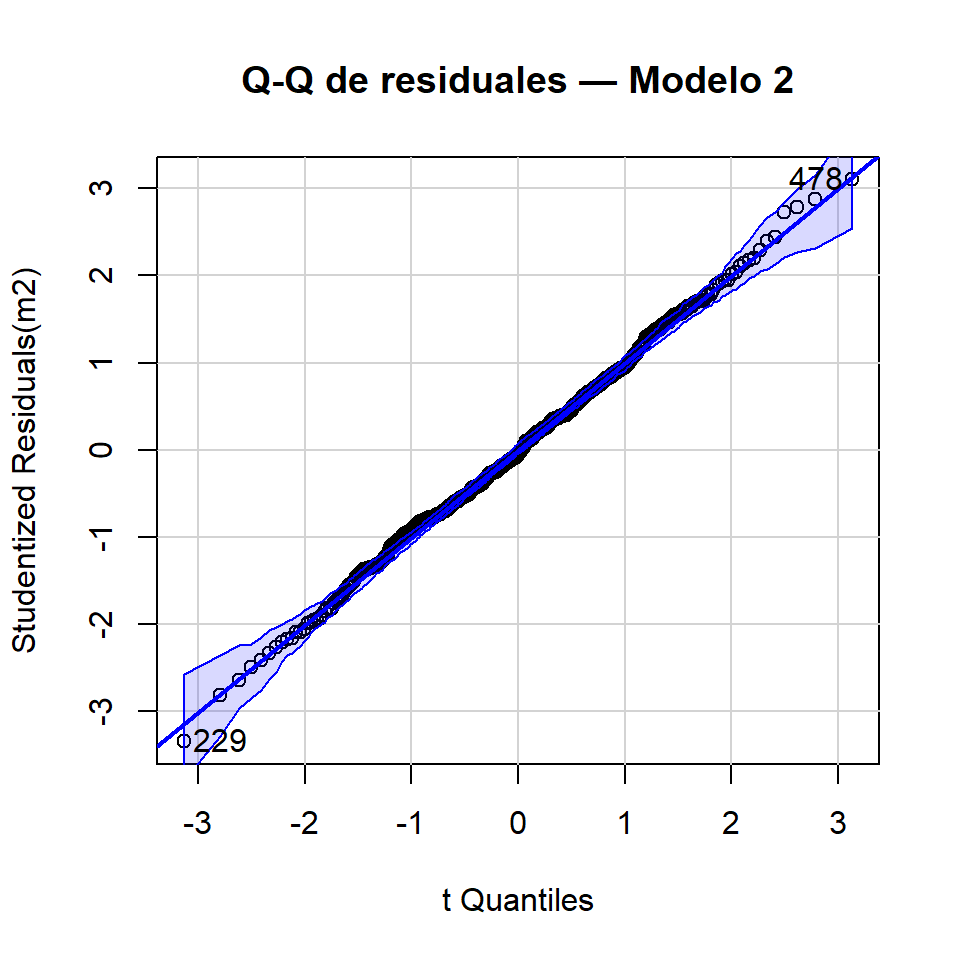

```
## [1] 229 478
```

```r
car::qqPlot(m2, simulate = TRUE, main = "Q-Q de residuales — Modelo 2")
```

### Multicolinealidad — VIF y número de condición

```r
cat("VIF — Modelo 2:\n")
```

```
## VIF — Modelo 2:
```

```r
print(car::vif(m2))
```

```
##          area         banos       garajes    elevadores       estrato
##      2.748238      2.141946      2.685322      1.197469      2.206036
##      porteria      zona_lav          casa casa_conjunto
##      1.060640      1.014918      1.100928      1.063767
```

```r
cat("\nNúmero de condición (kappa):\n")
```

```
##
## Número de condición (kappa):
```

```r
print(kappa(model.matrix(m2)))
```

```
## [1] 485.1673
```

### Observaciones influyentes

```r
n_m2 <- nobs(m2)
p_m2 <- length(coef(m2))

H      <- hatvalues(m2)
cook   <- cooks.distance(m2)
dff    <- dffits(m2)
res_stud <- rstudent(m2)
covr   <- covratio(m2)

thr_h   <- 2 * p_m2 / n_m2
thr_dff <- 2 * sqrt(p_m2 / n_m2)
thr_dfb <- 2 / sqrt(n_m2)

diag_tbl <- tibble::tibble(
  obs      = seq_len(n_m2),
  h_ii     = H,
  rstudent = res_stud,
  cookD    = cook,
  dffits   = dff,
  covratio = covr
) %>%
  mutate(
    flag_h    = h_ii     > thr_h,
    flag_rstu = abs(rstudent) > 2,
    flag_cook = cookD    > max(1, 4 / n_m2),
    flag_dff  = abs(dffits)   > thr_dff,
    flag_covr = (covratio < (1 - 3 * p_m2 / n_m2)) |
                (covratio > (1 + 3 * p_m2 / n_m2)),
    any_flag  = flag_h | flag_rstu | flag_cook | flag_dff | flag_covr
  )

cat("Observaciones con al menos un indicador de influencia:\n")
```

```
## Observaciones con al menos un indicador de influencia:
```

```r
print(diag_tbl %>% filter(any_flag) %>%
        arrange(desc(abs(rstudent))) %>% head(12))
```

```
## # A tibble: 12 × 12
##      obs    h_ii rstudent   cookD dffits covratio flag_h flag_rstu flag_cook
##    <int>   <dbl>    <dbl>   <dbl>  <dbl>    <dbl> <lgl>  <lgl>     <lgl>
##  1   229 0.0365     -3.35 0.0416  -0.651    0.861 TRUE   TRUE      FALSE
##  2   478 0.00623     3.10 0.00594  0.246    0.859 FALSE  TRUE      FALSE
##  3   443 0.0153      2.87 0.0127   0.359    0.889 FALSE  TRUE      FALSE
##  4   299 0.00495    -2.82 0.00390 -0.199    0.885 FALSE  TRUE      FALSE
##  5   282 0.0288      2.78 0.0226   0.479    0.910 FALSE  TRUE      FALSE
##  6    14 0.00518     2.72 0.00381  0.196    0.893 FALSE  TRUE      FALSE
##  7   506 0.0206     -2.64 0.0145  -0.382    0.915 FALSE  TRUE      FALSE
##  8   550 0.0247     -2.49 0.0156  -0.396    0.932 FALSE  TRUE      FALSE
##  9   354 0.0250      2.44 0.0151   0.390    0.937 FALSE  TRUE      FALSE
## 10   500 0.00492    -2.42 0.00286 -0.170    0.919 FALSE  TRUE      FALSE
## 11   398 0.00940     2.40 0.00541  0.234    0.925 FALSE  TRUE      FALSE
## 12    99 0.00838    -2.34 0.00457 -0.215    0.929 FALSE  TRUE      FALSE
## # ℹ 3 more variables: flag_dff <lgl>, flag_covr <lgl>, any_flag <lgl>
```

```r
cat("Prueba de outliers (Bonferroni):\n")
```

```
## Prueba de outliers (Bonferroni):
```

```r
print(car::outlierTest(m2))
```

```
## No Studentized residuals with Bonferroni p < 0.05
## Largest |rstudent|:
##      rstudent unadjusted p-value Bonferroni p
## 229 -3.345404         0.00087873      0.48418
```

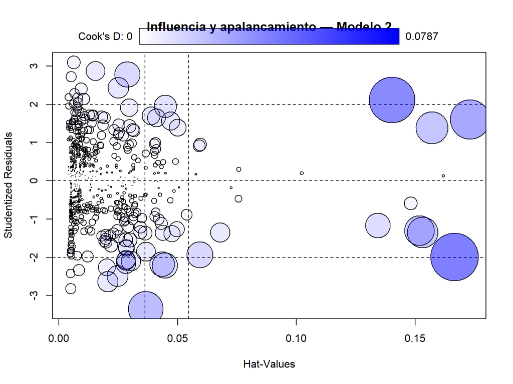

```r
car::influencePlot(
  m2,
  id   = list(method = "rstudent", n = 3),
  main = "Influencia y apalancamiento — Modelo 2"
)
```

# Comparación de bondad de ajuste

```r
tabla_comp <- data.frame(
  Modelo    = c("M0 — precio", "M1 — log(precio) completo", "M2 — log(precio) final"),
  n         = c(nobs(m0), nobs(m1), nobs(m2)),
  Variables = c(length(coef(m0)) - 1, length(coef(m1)) - 1, length(coef(m2)) - 1),
  R2        = c(summary(m0)$r.squared,     summary(m1)$r.squared,     summary(m2)$r.squared),
  R2_adj    = c(summary(m0)$adj.r.squared, summary(m1)$adj.r.squared, summary(m2)$adj.r.squared),
  AIC       = c(AIC(m0), AIC(m1), AIC(m2)),
  BIC       = c(BIC(m0), BIC(m1), BIC(m2))
)

tabla_comp %>%
  mutate(across(where(is.numeric), ~round(.x, 4)))
```

```
##                      Modelo   n Variables     R2 R2_adj        AIC        BIC
## 1               M0 — precio 551        16 0.9069 0.9041 21029.6416 21107.2528
## 2 M1 — log(precio) completo 551        16 0.8956 0.8925  -401.4508  -323.8396
## 3    M2 — log(precio) final 551         9 0.8944 0.8926  -409.0038  -361.5747
```

El Modelo 2 presenta el menor AIC y BIC entre los modelos con `log_precio`, y el mayor $\bar{R}^2$ ajustado, confirmándose como el mejor modelo: maximiza el ajuste mientras penaliza la complejidad innecesaria.

# Modelo final

Dado que la variable dependiente es $\log(\text{precio})$, los coeficientes se interpretan como **semielasticidades**: un incremento unitario en $X_j$ genera un cambio de $(e^{\hat{\beta}_j} - 1) \times 100\%$ en el precio.

```r
coefs <- coef(m2)[-1]
efectos <- data.frame(
  Variable   = names(coefs),
  Beta       = round(coefs, 4),
  Efecto_pct = round((exp(coefs) - 1) * 100, 2)
)
efectos
```

```
##                    Variable    Beta Efecto_pct
## area                   area  0.0073       0.74
## banos                 banos  0.1210      12.86
## garajes             garajes  0.1805      19.78
## elevadores       elevadores  0.0718       7.45
## estrato             estrato  0.1675      18.23
## porteria           porteria -0.0705      -6.81
## zona_lav           zona_lav  0.0560       5.76
## casa                   casa  0.1833      20.12
## casa_conjunto casa_conjunto  0.0934       9.79
```

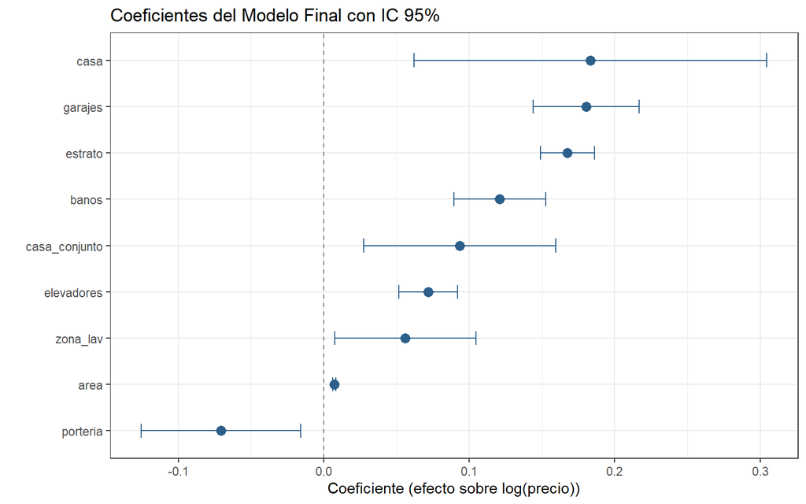

```r
coef_df <- data.frame(
  variable = names(coef(m2))[-1],
  estimado = coef(m2)[-1],
  lwr      = confint(m2)[-1, 1],
  upr      = confint(m2)[-1, 2]
)

ggplot(coef_df, aes(x = estimado, y = reorder(variable, estimado))) +
  geom_vline(xintercept = 0, linetype = "dashed", color = "gray50") +
  geom_errorbarh(aes(xmin = lwr, xmax = upr), height = 0.3, color = "#2C5F8A") +
  geom_point(size = 3, color = "#2C5F8A") +
  labs(title = "Coeficientes del Modelo Final con IC 95%",
       x = "Coeficiente (efecto sobre log(precio))",
       y = "") +
  theme_bw()
```